# task4 analysis

## Task 4: Alternative panel

### Introduction

From the in-class analysis, the data selected five proteins (DERM, RELT, MRC2, IgD, Cadherin-5) by intersecting the top 10 proteins from multiple testing and random forest importance. Then, a logistic regression was fitted on an 80/20 split. On that single split (31 test subjects) it achieved sensitivity 0.812, specificity 0.733, accuracy 0.774, and ROC AUC 0.883. This estimate is noisy and optimistic. The proteins were selected using all 154 subjects, including the test subjects.

### Method

In order to get a fairer benchmark, we evaluated every panel on the same 50 random 75/25 splits (stratified by group). For each split we:

1. Fit an L1-penalized (LASSO) logistic regression with 5-fold cross-validation on the **training data only**, and recorded the panel at `lambda.min` (best CV AUC) and `lambda.1se` (sparser).
2. Computed test AUROC for both LASSO panels using the LASSO’s own predictions.
3. Refit the in-class 5-protein panel on the training data and computed its test AUROC.

We counted how often each protein was selected by the `lambda.1se` LASSO across the 50 splits. Since the LASSO panels were not simpler or better, we took the three most frequently selected proteins, DERM, IgD, MAPK2, as a fixed alternative panel, and evaluated it with a logistic regression on the same 50 splits, alongside the in-class panel.

**Decision rule.**

A panel is counted as *improved* if its mean test AUROC exceeded the in-class panel’s by roughly one standard deviation across splits. It is counted as *simpler* if it used fewer than 5 proteins with mean AUROC and no more than roughly one standard deviation below the in-class panel’s. This is a heuristic, not a formal test. We compared against the in-class panel’s repeated-split AUROC, not the single-split 0.883, since the two are not measured the same way.

### Results

| Method | Mean test AUROC | SD | Mean panel size |
| --- | --- | --- | --- |
| In-class panel (baseline) | 0.806 | 0.062 | 5 |
| LASSO, `lambda.1se` | 0.784 | 0.066 | 15.5 |
| LASSO, `lambda.min` | 0.819 | 0.047 | 40.0 |

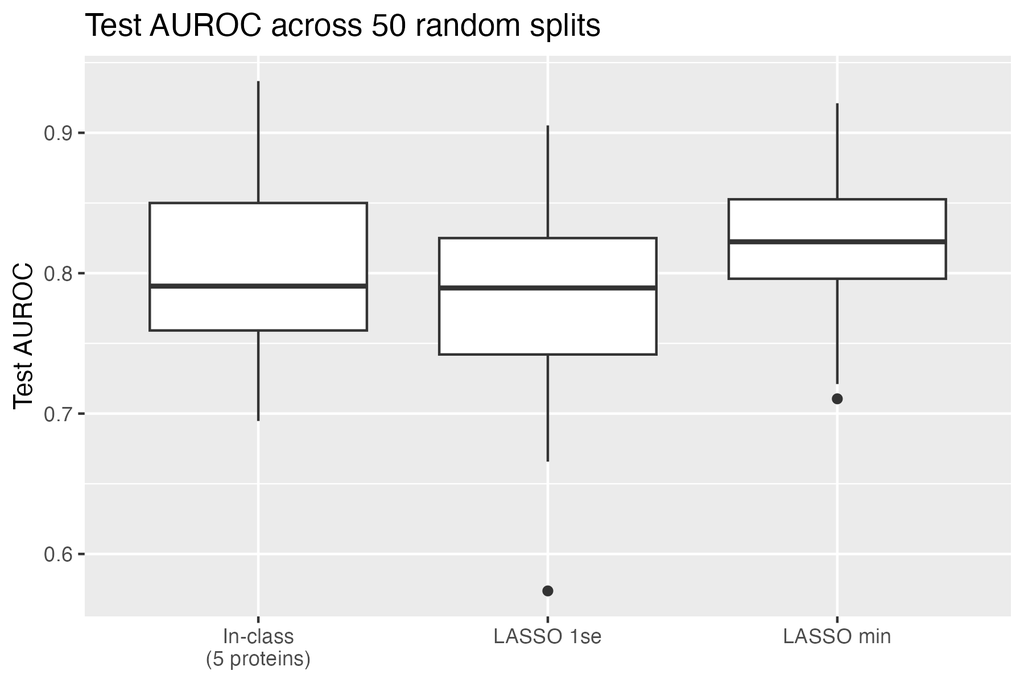

Test AUROC across 50 random splits: in-class panel vs. LASSO.

Neither LASSO panel met our criteria. `lambda.min` was higher than the baseline by only 0.013, less than one SD, while using about eight times as many proteins (40.0). `lambda.1se` was slightly worse and still larger than the baseline panel (15.5).

The most frequently selected proteins by the `lambda.1se` LASSO were DERM (48 of 50 splits), IgD (43), MAPK2 (41), 14-3-3 protein zeta/delta (26), and RELT (25). DERM, IgD, and RELT are in the in-class panel, MAPK2 and 14-3-3 protein zeta/delta are not, and MRC2 and Cadherin-5 from the in-class panel were not among the 15 most frequently selected.

Since the LASSO panels were not simpler or better, we evaluated a fixed 3-protein panel made of the three most frequently selected proteins (DERM, IgD, MAPK2) on the same 50 splits:

| Method | Mean test AUROC | SD | Proteins |
| --- | --- | --- | --- |
| In-class panel | 0.806 | 0.062 | 5 |
| 3 protein panel: DERM + IgD + MAPK2 | 0.848 | 0.046 | 3 |

Mean paired difference (3-protein minus in-class): 0.042 (SD 0.041).

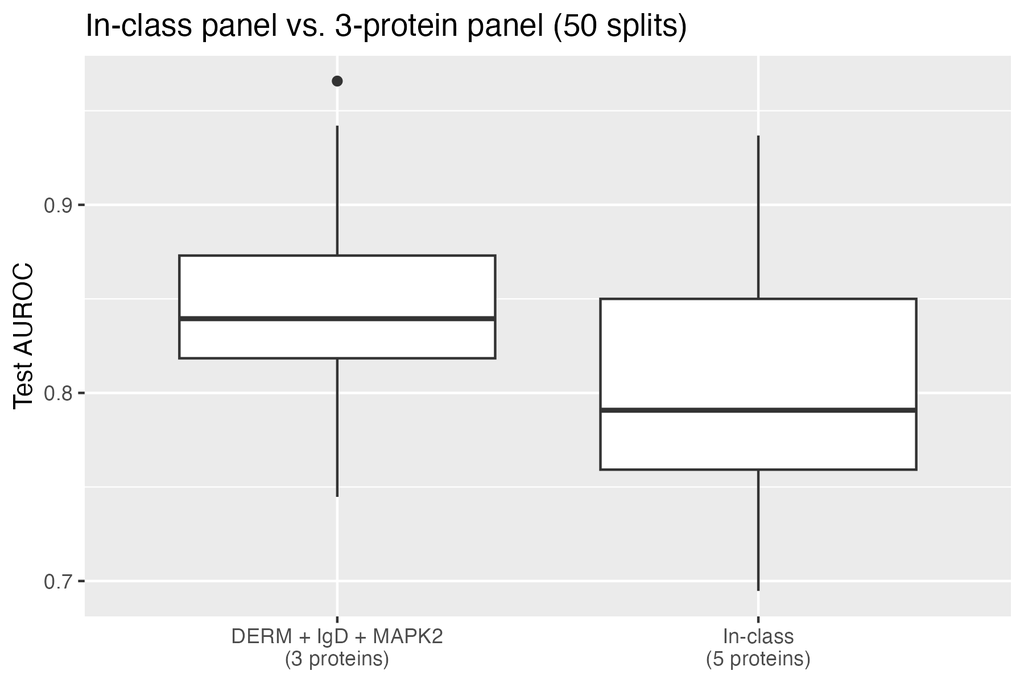

In-class panel vs. 3-protein panel across 50 splits.

### Conclusion

A 3-protein panel (DERM, IgD, MAPK2) achieved a mean test AUROC of 0.848 compared with 0.806 for the 5-protein in-class panel on the same 50 splits. Therefore, the 3-protein panel is a simpler panel that achieved a comparable AUROC. This is deemed as simpler under our decision rule since it uses fewer proteins and the AUROC is at least as high. The AUROC difference (+0.042) is smaller than one standard deviation of the in-class panel’s AUROC across splits (0.062), so it does not meet our criterion for an improved panel. We therefore claim comparable accuracy with fewer proteins, not a demonstrated gain in accuracy. Two of the three proteins (DERM, IgD) are in the in-class panel, and MAPK2 is not.

### Limitations

- The in-class single-split result (AUROC 0.883) and our repeated-split results are not directly comparable. The in-class panel’s mean AUROC across 50 splits (0.806) is a more realistic estimate of its accuracy.
- The in-class panel was selected using all 154 subjects, and the 3-protein panel was chosen using selection counts across all 50 splits. In both cases the test data influenced the choice, so both estimates are somewhat optimistic.
- With 154 subjects, AUROC varies noticeably across splits (SD about 0.05 to 0.07), so small differences between panels should not be over-interpreted.